# Maps

It's hardly worth pointing out that you use a map only for data with some geographical connection. The visual complexity belies the fact that maps allow only one or two variables to be displayed — the spatial component of the graphic is entirely given over to the geography.

Making a map, given the right tools, is very simple. You need only create a table that identifies each geographical entity with a value for a variable. Then you hand things over to software which includes:

- a database that contains information about the geographical entities.
- mathematical projections that turn geographical position into position on the diagram. Two commonly used projections are [Mercator](http://en.wikipedia.org/wiki/Mercator_projection) and [Peters](http://en.wikipedia.org/wiki/Gall%E2%80%93Peters_projection).

Our goal here is to examine the basic principles of representation of data on a map. For simplicity, we'll emphasize country-by-country maps of the world. In such maps, the geographical entity is a country. The data value for each country is generally presented as a color.

> The software you'll use for interactive drawing of world maps is `mWorldMap`, which you can use in much the same way as `mScatter` and `mBar`. In writing up your documents, cut and paste the command generated by `mWorldMap` into your .Rmd document so that the graph will be generated on the fly.

The most familiar way to color a map is to show each country colored in. Here, for example, is a map of per-capita alcohol consumption:

```r
alc = fetchGapminder("Gapminder/Alcohol.csv")
```

```
## Retrieving from
## http://www.mosaic-web.org/go/datasets/Gapminder/Alcohol.csv
```

```
## 182 codes from your data successfully matched countries in the map
## 7 codes from your data failed to match with a country code in the map
## 61 codes from the map weren't represented in your data
```

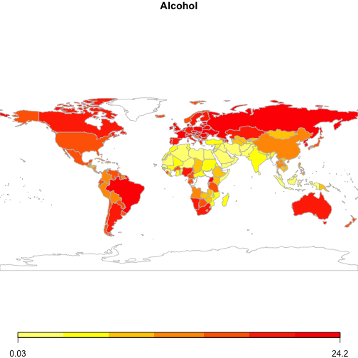

```r
amean = groupBy(alc, by = Country, Alcohol = max(Alcohol))
{
    .s. <- joinCountryData2Map(amean, joinCode = "NAME", nameJoinColumn = "Country")
    par(mai = c(0, 0, 0.2, 0), xaxs = "i", yaxs = "i")
    .mp. <- mapCountryData(.s., nameColumnToPlot = "Alcohol", addLegend = FALSE,
        mapRegion = "world")
    do.call(addMapLegend, c(.mp., legendWidth = 0.5, legendMar = 2))
}
```

```r
traf = fetchGapminder("Gapminder/TrafficDeathRate.csv")
```

```
## Retrieving from
## http://www.mosaic-web.org/go/datasets/Gapminder/TrafficDeathRate.csv
```

```r
tmean = groupBy(traf, by = Country, deaths = mean(TrafficDeathRate))
both = join(tmean, amean)
```

```
## 197 codes from your data successfully matched countries in the map
## 14 codes from your data failed to match with a country code in the map
## 51 codes from the map weren't represented in your data
```

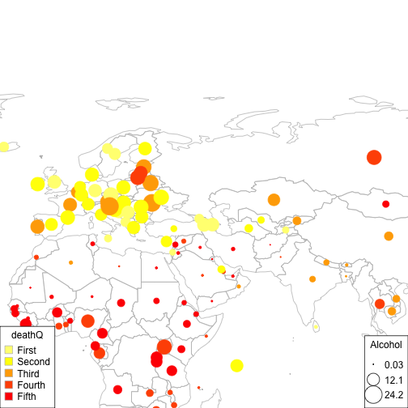

```r
both = transform(both, deathQ = ntiles(deaths, 5), alcQ = ntiles(Alcohol, 5))
{
    .s. <- joinCountryData2Map(both, joinCode = "NAME", nameJoinColumn = "Country")
    par(mai = c(0, 0, 0.2, 0), xaxs = "i", yaxs = "i")
    .mp. <- mapBubbles(.s., nameZColour = "deathQ", nameZSize = "Alcohol", mapRegion = "eurasia")
}
```

The principles are broadly the same for all sorts of maps. For instance, the Peters projection map below shows surface aspect of areas: e.g. desert, water, vegetated, ice. The geographical entityis a small area of the earth's surface; the color is selected to indicate on a familiar, intuitive scale the type of surface.

[figure not shown]

Notice that there is a continuum of colors in the map above. People are good at distinguishing small color changes between adjacent patches. But people aren't so good at comparing colors between distant patches. For this reason, the bubble-plot map works well when the colors fall into just a handful of categories. When plotting out two quantitative variables, there is a choice to be made about which variable should be assigned to the color of the bubbles and which to the size. For instance, here is a map about alcohol consumption and traffic deaths that uses bubble size to indicate the death rate.

```
## 197 codes from your data successfully matched countries in the map
## 14 codes from your data failed to match with a country code in the map
## 51 codes from the map weren't represented in your data
```

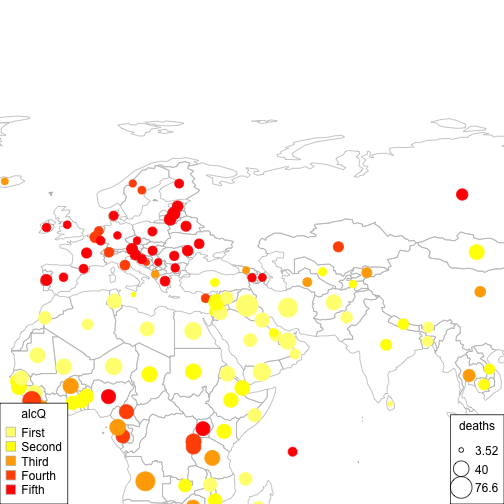

```r
{
    .s. <- joinCountryData2Map(both, joinCode = "NAME", nameJoinColumn = "Country")
    par(mai = c(0, 0, 0.2, 0), xaxs = "i", yaxs = "i")
    .mp. <- mapBubbles(.s., nameZColour = "alcQ", nameZSize = "deaths", mapRegion = "eurasia")
}
```

### Exercises:

#### Exercise 1

Make a world map in which the population of each country is indicated by a color.

#### Exercise 2

Make a world map in which the population of each country is indicated by the size of a circle.

#### Exercise 3

Make a world map in which the population density of each country is indicated by a color.

#### Exercise 4

Make a map, like this, that correlates traffic deaths with fraction of roads that are paved. (See `PavedRoads.csv` in the Gapminder data.)

```
## Retrieving from
## http://www.mosaic-web.org/go/datasets/Gapminder/PavedRoads.csv
```

```
## 201 codes from your data successfully matched countries in the map
## 12 codes from your data failed to match with a country code in the map
## 42 codes from the map weren't represented in your data
```

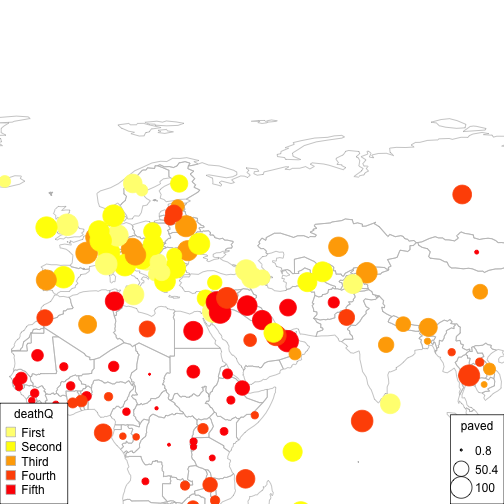

- What sort of correlation is there between fraction of roads paved and traffic death rates?
- Are there countries that stand out of the trend? Which ones

Make a scatter plot of the traffic death rate, fraction of paved roads, and alcohol consumption per capita. Compare the map portrayal to the scatter plot — which one makes it easier to see various patterns.

#### For Next Week

We'll do join next week in a more serious way.

- Identify each country with a region, using the region information in the scatter plot.
- Clean the species variable in the bird data.